# My Cats

Hannah Salomon

February 18, 2018

## Description

I have two wonderful cats, which are the loves of my life. They are very dependent compared to most cats, and sometimes they act more like dogs. But I love them just the same.

The names of my cats are:

- Sunny
- Karma

They are two different breeds:

| Cat | Breed |
| --- | --- |
| Sunny | Maine Coon |
| Karma | Short-haired domestic |

### Sunny

Sunny is a 7-year-old female. She is a Maine Coon and quite the diva. Her favorite things to do are as follows:

1. Retrieve toys in exchange for treats
2. Meow in the middle of the night and wake everyone up
3. Sleep

### Karma

Karma is a 6-year-old male. He is a short-hair domestic cat with slightly special needs. He is the sweetest Mama’s boy of a cat. His favorite things to do are as follows:

1. Get attention
2. Chase his sister around the house at odd hours of the night
3. Find warm places to sleep

## Do you like cats?

If you or anyone you know are thinking about adopting a cat, there are plenty of reputable adoption agencies in the area:

- Pennsylvania SPCA
- ACCT Philly +Animal Care & Control Team of Philadelphia
- PAWS
- Philadelphia Animal Welfare Society

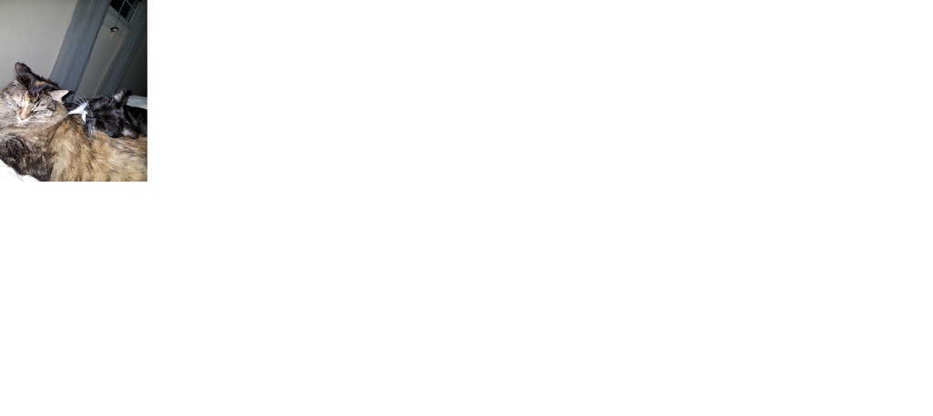